# Gradient Forest - Identification of outlier SNPs

Published

November 29, 2024

```r
# Function to make the Venn diagrams
make_venndiagram <- function(list_candidates,
                             caption="",
                             title=""){

list_candidates %>%
    ggVennDiagram(lty="solid", size=0.2, label = "count", label_alpha=0,edge_size = 0.7) +
  scale_fill_gradient2(low = "white", high = 'darkgoldenrod3') +
  scale_color_manual(values = rep("darkgoldenrod1",6)) +
  guides(fill = "none") +
  labs(caption=caption) +
  ggtitle(title) +
  theme(text = element_text(size=16),
        plot.caption = element_text(hjust=0.5, size=rel(1.2))) +
  scale_x_continuous(expand = expansion(mult = .2))
}
```

# Introduction

The analyses conducted in the present report were conducted following Fitzpatrick et al. (2021) and Capblancq et al. (2023), and the R code is based on [the github repository](https://github.com/fitzLab-AL/geneticOffsetR) associated with Fitzpatrick et al. (2021).

**Goal:** Identify outlier SNPs that show association with climatic variables and may be considered as potential candidates for local adaptation to climate using the Gradient Forest (GF) algorithm.

To this goal, we will apply the GF algorithm to:

- the *raw* or *uncorrected* allele frequencies (*GF-raw* in Fitzpatrick et al. (2021) and Capblancq et al. (2023)).
- the *corrected* allele frequencies, i.e. the allele frequencies corrected for population structure = corrected for population relatedness. In Fitzpatrick et al. (2021) and Capblancq et al. (2023), they use the population genetic variance-covariance matrix from Bayenv 2 to correct for population structure and called the matrix of corrected allele frequencies *GF-X*. From Fitzpatrick et al. (2021): ‘The GF-X approach was included to explore a more robust approach to allele frequency estimation that corrects for finite sampling and population relatedness prior to feeding into GF for outlier detection.’ In our case, we extract the matrix of corrected allele frequencies using the latent factor mixed model (LFMM) approach; see section 5 ‘Corrected allele frequencies’ in the `6_LEAanalysis.qmd` report.

**Strengths** of the GF algorithm: nonparametric (nonlinear allele frequency gradients), makes no assumption about the particular form of the gene–climate relationships, incorporates multivariate predictors, interactions among predictors.

**Weakness**: not controlling for demographic history.

From Gain et al. (2023): ‘Nonlinearity makes the GF model more flexible than linear models, but the additional degrees of freedom may not always be desirable when resolving bias-variance trade-offs.’

**The approach with empirical $p$-values**

In Fitzpatrick et al. (2021) and Capblancq et al. (2023), GF models are fitted to each locus individually and $R^2$ is calculated for each locus. Empirical $p$-values are then calculated. The empirical $p$-value approach is described in Lotterhos and Whitlock (2014): ‘[…] if the set of neutral loci is large enough, the statistical significance of a putatively selected outlier locus could be assessed by its quantile in the empirical distribution of differentiation measures obtained from the neutral set.’

In Fitzpatrick et al. (2021), the authors use a set of intergenic SNPs to obtain a distribution of $R^2$ values, which is considered as the empirical null distribution of $R^2$ values. They calculate the empirical $p$-values by determining the rank of the $R^2$ value for each locus within the distribution of $R^2$ values from the intergenic SNPs.

In the present report, we use all SNPs to build the distribution of $R^2$ values that we then compare with the $R^2$ value of each locus. Thus, the empirical $p$-value $\hat{p}$ of the locus $l$ is equal to:

$$\hat{p}_l = 1 - (r_l / N)$$
with $r_l$ being the rank of the $R^2$ value of locus $l$ within the distribution of $R^2$ values of all SNPs ($N$ SNPs).

However, if I’m not misleading, selecting the SNPs based on the rank of their empirical $p$-value is equivalent to selecting them based on the rank of their $R^2$, i.e., the 0.2% or 0.5% of the SNPs with the highest $R^2$ should match the 0.2% or 0.5% of the SNPs with the lowest empirical $p$-value. We check in this report that this is the case.

**Warning:** Gradient Forest has only been used once as a genome scan (Capblancq et al. 2023) and its ability to identify loci underlying local adaptation has still not been evaluated and confronted to other GEAs. This method does not provide a significance level for each SNPs that we can use to select the candidate SNPs and therefore we have to use empirical $p$-values, which may be less robust. Moreover, when we performed several runs of GF as a genome scan, we did not obtain the same exact set of candidate SNPs each time. Another observation that made us skeptical of GF is that no common candidates were found between GF and GF-X (although we do not expect much overlap, it is still unexpected that there is no overlap at all).

For these reasons, we have to be careful when using this method as a GEA. In our study, we finally did not use *GF-X*. And because the SNPs with the lowest empirical $p$-values were not exactly the same across independent runs of *GF-raw*, we ran 3 independent runs, identified the 0.5% with the lowest empirical $p$-values for each run (i.e. 49 SNPs) and then considered as outlier SNPs the SNPs identified in the three runs.

# Options, parameters and functions

## Functions from Fitzpatrick et al. (2021)

The following functions are based on the functions written by MC Fitzpatrick (Appalachian Lab, Frostburg, MD) and available in the Github repository: https://github.com/fitzLab-AL/geneticOffsetR

### `format_geno`

Function to format the genomic data used in the GF analysis.

Inputs:

- `genodata`: the genomic dataset with SNPs in columns and populations in rows (with population names as row names)
- `selected_snps`: SNPs selected for the analysis. If ‘all’, all SNPs are selected.
- `rm_rare_alleles`: specify whether rare alleles are removed or not. The rare alleles are the alleles that are polymorphic in fewer than five populations.

```r
format_geno <- function(genodata, selected_snps, rm_rare_alleles){

  # run GF on all SNPs or a subset of selected SNPs?
  if(length(selected_snps)>1){genodata <- genodata %>% dplyr::select(all_of(selected_snps))}

  # remove SNPs that are polymorphic in fewer than five populations?
  if(rm_rare_alleles==T){genodata  <- genodata %>% dplyr::select(which(unlist(lapply(lapply(., unique), length))>=6))}

  return(genodata)
  }
```

### `run_gf_ind`

Function to run the GF models individually for each locus.

Inputs:

- `genodata`: the genomic dataset with SNPs in columns and populations in rows (with population names as row names)
- `climdata`: table with the climatic variables with a row for each population
- `clim_var`: vector with the names of the climatic variables to be used in the GF models
- `ntree`: number of trees to fit
- `cores`: number of processors to use
- `set_seed_df`: dataset containing the seed to use before running the GF models (for reproductibility).

```r
run_gf_ind <- function(genodata, climdata, clim_var, ntree, cores, set_seed_df){

  # create custom object to hold output
  gf_output_obj <- setClass("gf_output_obj", slots = c(gf_data="data.frame", gf_impts="list"))

  # check that populations are in the same order in the genomic and climatic datasets
  if(identical(climdata$pop,rownames(genodata))==F){
    stop("Populations are not in the same order in the genomic and climatic tables.")
  }

  # check to make sure user has set the number of cores (min = 1)
  if(is.na(cores)){
    stop(paste0("You need to provide the number of processors to use (i.e., cores = 4). You have a maximum of ", detectCores(), " cores available."))
  }

  if(cores>detectCores()){
    stop(paste0("You have a maximum of ", detectCores(), " cores available."))
  }


    # fit the GF model to each SNP individually and in parallel
    cl <- makeCluster(cores, setup_strategy = "sequential")
    registerDoParallel(cl)

    gf_impts <- foreach(k=1:ncol(genodata), .verbose=F, .packages=c("gradientForest"), .errorhandling = "remove") %dopar%{
      locus <- data.frame(genodata[,k])
      names(locus) <- colnames(genodata)[k]
      set.seed(set_seed_df$seed_nb[set_seed_df$seed_ID== names(locus) ]) # for reproductibility
      gf_mod <- gradientForest(data.frame(climdata[, clim_var], locus),
                               predictor.vars=clim_var, response.vars=colnames(genodata)[k],
                               corr.threshold=0.5, ntree=ntree, trace=F)

      if(!is.null(gf_mod)){data.frame(variable=names(importance(gf_mod)),
                                      impts = importance(gf_mod),
                                      snp = colnames(genodata)[k])}
    }

    stopCluster(cl)


    return(gf_output_obj(gf_data = data.frame(genodata), gf_impts = gf_impts))

  }
```

### `extract_pvals`

Function to calculate the empirical p-values

Inputs:

- `gf_outputs`: output object from `run_gf_ind` function
- `neutral_snps`: subset of randomly selected SNPs used as ‘neutral’ SNPs to develop the empirical null model

```r
extract_pvals <- function(gf_outputs){

# Extract the R2 importance values from the GF outputs and arrange them in a
  # dataframe with a row for each SNP with R2>0 and a column with the R2 of each climatic variable
gf_R2 <-  gf_outputs@gf_impts %>%
    bind_rows() %>%
    pivot_wider(names_from = "variable", values_from = "impts") %>%
    rowwise() %>%
    mutate(totalR2 = sum(c_across(where(is.numeric)))) %>%
    arrange(snp)

# Extend the table to all the SNPs used in the GF analysis
  # attributing R2 = 0 to SNPs that were not included in gf_outputs because they did not have R2>0
dat <- gf_outputs@gf_data %>%
    t() %>%
    as.data.frame() %>%
    rownames_to_column("snp") %>%
    dplyr::select(snp) %>%
    as_tibble() %>%
    left_join(gf_R2, by="snp") %>%
    mutate(across(where(is.numeric), ~replace_na(.x, 0)))

# Using all SNPs to build the distribution of random SNPs
pV <- sapply(1:nrow(dat), function(x, dat){
    snps2Rank <- rbind(dat[x,], dat) %>%
      distinct() %>%
      dplyr::select(-snp)
    P <- apply(snps2Rank, 2, function(y){
      rankSNP <- frank(y)
      return(1-rankSNP[1]/length(rankSNP))
    })}, dat)

# Format output as data.frame
  pV <- t(pV)
  colnames(pV) <- paste("pval_", colnames(pV), sep="")
  pV <- data.frame(dat, pV)
  return(pV)
}
```

### `identify_GFoutliers`

Function to identify the GF outliers

Inputs:

- `list_clim_var`: list of vectors with the names of the climatic variables to be used in the GF models
- `nb_neutral_snps`: number of random SNPs to sample from the genomic data to develop the empirical null model
- `set_seed`: seed to use for sampling random integer for each SNP (and one for sampling the control SNPs), that will then be used in `set.seed` before running the GF models.

```r
identify_GFoutliers <- function(genodata,
                                climdata,
                                clim_var,
                                set_seed,
                                ntree,
                                rm_rare_alleles,
                                selected_snps,
                                cores){

# For reproductibility
set.seed(set_seed)
set_seed_df <- tibble(seed_ID = colnames(genodata),
                      seed_nb = sample(1:100000, ncol(genodata), replace=F))

# Filter the genomic data (allow to subset the SNPs and remove the polymorphic SNPs)
genodata <- format_geno(genodata,
                        selected_snps,
                        rm_rare_alleles)

# # we sample random SNPs that are considered as neutral SNPs
# set.seed(set_seed_df$seed_nb[set_seed_df$seed_ID=="neutral_snps"])
# neutral_snps <- sample(colnames(genodata),nb_neutral_snps,replace = F)

# We run the GF models individually for each SNP
gf_outputs <-  run_gf_ind(genodata = genodata, climdata = climdata, clim_var = clim_var, ntree = ntree, cores, set_seed_df = set_seed_df)

# We calculate the empirical p-values for each SNP
gf_pvals <- extract_pvals(gf_outputs=gf_outputs)

gf_out <- list(genodata = genodata,
               clim_var= clim_var,
               gf_pvals = gf_pvals)

return(gf_out)
}
```

# Downloading the data

## Genomic data

We load the *uncorrected* and *corrected* allele frequency matrices in a list.

```r
# we load the two genomic matrices
list_geno <- list(mat_raw = read.csv(here::here("data/DryadRepo/ImputedGenomicData_AlleleFrequencies_withoutmaf.csv"),
                                     row.names = 1),
                  mat_X = read.csv(here::here("data/GenomicData/CorrectedAlleleFrequencies_withoutmaf.csv"),
                                     row.names = 1))
```

The *uncorrected* allele frequency matrix is already a matrix a population-level allele frequencies, i.e. so with the number of populations in rows and the number of genetic markers in columns.

```r
list_geno$mat_raw[1:10,1:10] %>% kable_mydf()
```

|  | snp_2 | snp_3 | snp_4 | snp_5 | snp_6 | snp_7 | snp_8 | snp_9 | snp_10 | snp_12 |
| --- | --- | --- | --- | --- | --- | --- | --- | --- | --- | --- |
| ALT | 0.06 | 0.00 | 0.12 | 0.00 | 0.00 | 0.19 | 0.06 | 0.00 | 0.00 | 0.25 |
| ARM | 0.00 | 0.21 | 0.14 | 0.00 | 0.00 | 0.36 | 0.00 | 0.07 | 0.00 | 0.14 |
| ARN | 0.04 | 0.07 | 0.11 | 0.00 | 0.04 | 0.46 | 0.07 | 0.00 | 0.11 | 0.04 |
| BAY | 0.31 | 0.04 | 0.15 | 0.04 | 0.00 | 0.15 | 0.04 | 0.00 | 0.04 | 0.19 |
| BON | 0.19 | 0.50 | 0.12 | 0.12 | 0.00 | 0.75 | 0.00 | 0.00 | 0.12 | 0.19 |
| CAD | 0.06 | 0.19 | 0.00 | 0.00 | 0.06 | 0.44 | 0.00 | 0.00 | 0.19 | 0.25 |
| CAR | 0.20 | 0.00 | 0.20 | 0.00 | 0.10 | 0.10 | 0.20 | 0.00 | 0.00 | 0.10 |
| CAS | 0.00 | 0.00 | 0.00 | 0.00 | 0.00 | 0.12 | 0.06 | 0.06 | 0.00 | 0.31 |
| CEN | 0.11 | 0.17 | 0.06 | 0.00 | 0.00 | 0.39 | 0.06 | 0.00 | 0.06 | 0.06 |
| COC | 0.20 | 0.13 | 0.20 | 0.00 | 0.00 | 0.53 | 0.13 | 0.03 | 0.07 | 0.10 |

The *corrected* allele frequency matrix is a matrix of genotype-level (ie individual-level) allele frequencies, i.e. so with the number of genotypes (ie clones, individuals) in rows and the number of genetic markers in columns. We have to transform it in a population-level allele frequency matrix.

```r
# we calculate the population-level allele frequencies for the corrected matrix
list_geno$mat_X <- list_geno$mat_X %>%
  rownames_to_column(var="pop") %>%
  mutate(pop=str_sub(pop,1,3)) %>%
  group_by(pop) %>%
  summarise_all(~sum(., na.rm = TRUE)/((n()-sum(is.na(.)))*2)) %>%
  column_to_rownames("pop")

list_geno$mat_X[1:10,1:10] %>% kable_mydf()
```

|  | snp_2 | snp_3 | snp_4 | snp_5 | snp_6 | snp_7 | snp_8 | snp_9 | snp_10 | snp_12 |
| --- | --- | --- | --- | --- | --- | --- | --- | --- | --- | --- |
| ALT | 0.01 | 0.07 | -0.02 | 0.04 | 0.07 | 0.01 | 0.01 | -0.02 | 0.02 | 0.04 |
| ARM | 0.01 | 0.08 | -0.02 | 0.04 | 0.07 | 0.00 | 0.00 | -0.03 | 0.02 | 0.04 |
| ARN | -0.06 | -0.05 | -0.01 | -0.05 | -0.11 | 0.04 | -0.02 | 0.06 | -0.02 | -0.09 |
| BAY | 0.06 | 0.02 | 0.01 | -0.02 | -0.01 | -0.03 | -0.05 | 0.00 | -0.07 | -0.07 |
| BON | 0.04 | 0.03 | -0.01 | -0.03 | -0.02 | -0.01 | -0.06 | 0.01 | -0.05 | -0.08 |
| CAD | -0.01 | 0.00 | 0.02 | 0.04 | 0.09 | 0.00 | 0.02 | -0.04 | 0.02 | 0.13 |
| CAR | 0.11 | 0.00 | 0.02 | -0.02 | -0.04 | -0.06 | 0.01 | 0.00 | -0.04 | -0.10 |
| CAS | -0.03 | 0.00 | 0.01 | 0.04 | 0.07 | 0.03 | 0.03 | -0.02 | 0.03 | 0.11 |
| CEN | -0.01 | 0.06 | -0.07 | -0.06 | -0.08 | 0.01 | -0.06 | 0.04 | 0.01 | -0.15 |
| COC | 0.12 | -0.02 | 0.03 | -0.01 | -0.05 | -0.07 | 0.02 | 0.01 | -0.04 | -0.10 |

**Comment:** This data contains the population-based allele frequencies of the **minor allele**. The minor allele was identified as the minor allele across all individuals. However, as the populations do not contain the same number of individuals, the average of the population-based allele frequencies is higher than 0.5 for some SNPs.

```r
high_freqs <- lapply(list_geno, function(x)

  x %>%
  summarise_all(mean) %>%
  pivot_longer(everything(),names_to = "snp",values_to= "mean") %>%
  filter(mean>0.5))
```

For the corrected matrix, 0 have average population-based allele frequencies higher than 0.5. However, for the uncorrected matrix, 168 SNPs have average population-based allele frequencies higher than 0.5. Can we still call them population minor allele frequencies?

## Climatic data

We load the population-specific climatic information for the climatic variables of interest.

```r
# Selected climatic variables
# ===========================
clim_var <- readRDS(here("data/ClimaticData/NamesSelectedVariables.rds"))

extract_climatedt_metadata(var_clim = clim_var) %>%
  dplyr::select(label,description,unit) %>%
  set_colnames(str_to_title(colnames(.))) %>%
  kable_mydf()
```

| Label | Description | Unit |
| --- | --- | --- |
| bio1 | Mean annual temperature | Celsius degrees (°C) |
| bio3 | Isothermality (bio2/bio7) (×100) | index |
| bio4 | Temperature seasonality (standard deviation ×100) | Celsius degrees (°C) |
| bio12 | Annual precipitation | Millimeters (mm) |
| bio15 | Precipitation seasonality (coefficient of variation) | index |
| SHM | Summer heat moisture index | °C / mm |

```r
# Past and future climatic data
# =============================
source(here("scripts/functions/generate_scaled_clim_datasets.R"))
clim_ref <- generate_scaled_clim_datasets(clim_var)[[1]]
```

# Run GF models and calculate empirical $p$-values

We run the GF models successively for each SNP, and for both the raw allele frequencies and the corrected allele frequencies. Empirical p-values are then calculated based on the $R^2$ obtained for each locus.

However, outlier SNPs identified across successive runs are not exactly the same.

Therefore, we run the GF models three times, each time with a different `set_seed`.

```r
set_seed_numbers <- c(4930,394,442)

lapply(set_seed_numbers, function(set_seed){

gf_out <- lapply(list_geno, function(geno)

identify_GFoutliers(genodata = geno,
                    climdata = clim_ref,
                    clim_var = clim_var,
                    rm_rare_alleles = T,
                    set_seed = set_seed,
                    selected_snps = "all",
                    ntree=500,
                    cores = 8)) %>%
  setNames(c("gf_raw","gf_X"))

saveRDS(gf_out, here(paste0("outputs/GF/GFmodels_seed",set_seed,".rds")))

})
```

# Identify outliers

We try different thresholds to identify the outlier SNPs:

```r
list_gf_out <- list(readRDS(here::here("outputs/GF/GFmodels_seed4930.rds")),
                    readRDS(here::here("outputs/GF/GFmodels_seed394.rds")),
                    readRDS(here::here("outputs/GF/GFmodels_seed442.rds")))

list_gf_outliers <- lapply(list_gf_out, function(gf_out){

gf_outliers <- lapply(gf_out, function(x){

# Thresholds based on the empirical p-values
outliers_epv_005 <- x$gf_pvals %>% filter(pval_totalR2<0.05) %>% pull(snp) # this threshold is not enough strict
outliers_epv_001 <- x$gf_pvals %>% filter(pval_totalR2<0.01) %>% pull(snp)

# Thresholds based the p-value rank of the SNPs
# 0.2% with the lowest p-value (19 SNPs)
outliers_epv_rank_002 <- x$gf_pvals %>%
  arrange(pval_totalR2) %>%
  slice(1:(dim(list_geno[[1]])[[2]]*0.002)) %>%
  pull(snp)

# 0.5% with the lowest p-value (49 SNPs)
outliers_epv_rank_005 <- x$gf_pvals %>%
  arrange(pval_totalR2) %>%
  slice(1:(dim(list_geno[[1]])[[2]]*0.005)) %>%
  pull(snp)

# Threshold with a Bonferroni correction
outliers_epv_bonf <- x$gf_pvals %>%
  filter(pval_totalR2<0.01/length(x$gf_pvals$snp)) %>%
  pull(snp)

# Threshold based on the R2 rank of the SNPs
# 0.2% with the highest R2 (19 SNPs)
outliers_R2_rank_002 <- x$gf_pvals %>%
  arrange(desc(totalR2)) %>%
  slice(1:(dim(list_geno[[1]])[[2]]*0.002)) %>%
  pull(snp)

# 0.5% with the highest R2 (49 SNPs)
outliers_R2_rank_005 <- x$gf_pvals %>%
  arrange(desc(totalR2)) %>%
  slice(1:(dim(list_geno[[1]])[[2]]*0.005)) %>%
  pull(snp)

list(outliers_epv_005 = outliers_epv_005,
     outliers_epv_001 = outliers_epv_001,
     outliers_epv_rank_002 = outliers_epv_rank_002,
     outliers_epv_rank_005 = outliers_epv_rank_005,
     outliers_epv_bonf = outliers_epv_bonf,
     outliers_R2_rank_002 = outliers_R2_rank_002,
     outliers_R2_rank_005 = outliers_R2_rank_005)
})

})

saveRDS(list_gf_outliers, here::here("outputs/GF/GFoutliers_ThreeRuns.rds"))
```

We check that the outlier SNPs identified with 0.2% or 0.5% highest $R^2$ are the same as the one identified with the 0.2% or 0.5% lowest empirical $p$-values.

```r
lapply(list_gf_outliers, function(run_i){

  lapply(run_i, function(x){

identical(sort(run_i$x$outliers_R2_rank_002),sort(run_i$x$outliers_epv_rank_002))
identical(sort(run_i$x$outliers_R2_rank_005),sort(run_i$x$outliers_epv_rank_005))

  })
}) %>% setNames(paste0("run",1:3))
```

```
$run1
$run1$gf_raw
[1] TRUE

$run1$gf_X
[1] TRUE


$run2
$run2$gf_raw
[1] TRUE

$run2$gf_X
[1] TRUE


$run3
$run3$gf_raw
[1] TRUE

$run3$gf_X
[1] TRUE
```

# Unstable outlier identification across runs

The Venn diagrams below show the number of SNPs in common across the three independent runs, using the rank-based thresholds (0.2% or 0.5% of the SNPs with the lowest p-values).

## Raw allele frequencies

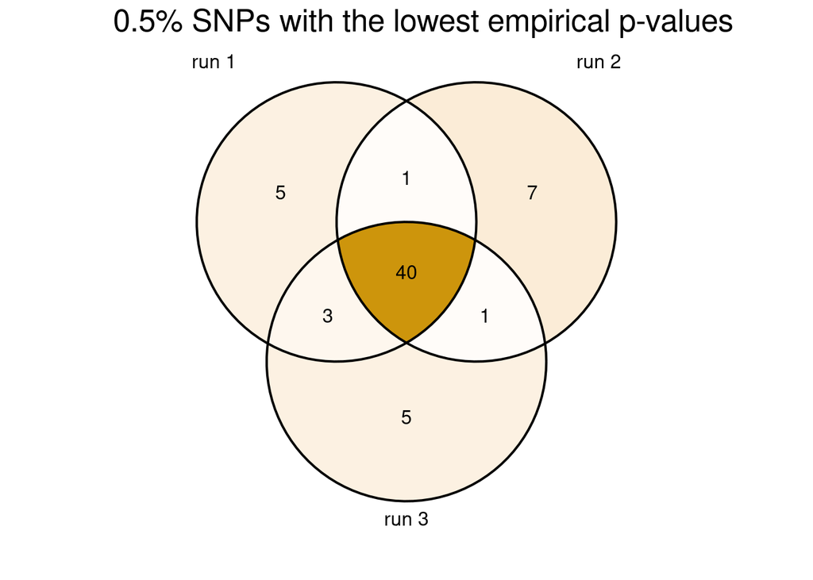

```r
list_gf_outliers <- readRDS(here::here("outputs/GF/GFoutliers_ThreeRuns.rds"))

list("run 1"=list_gf_outliers[[1]]$gf_raw$outliers_epv_rank_005,
     "run 2"=list_gf_outliers[[2]]$gf_raw$outliers_epv_rank_005,
     "run 3"=list_gf_outliers[[3]]$gf_raw$outliers_epv_rank_005) %>%
  make_venndiagram(title="0.5% SNPs with the lowest empirical p-values")
```

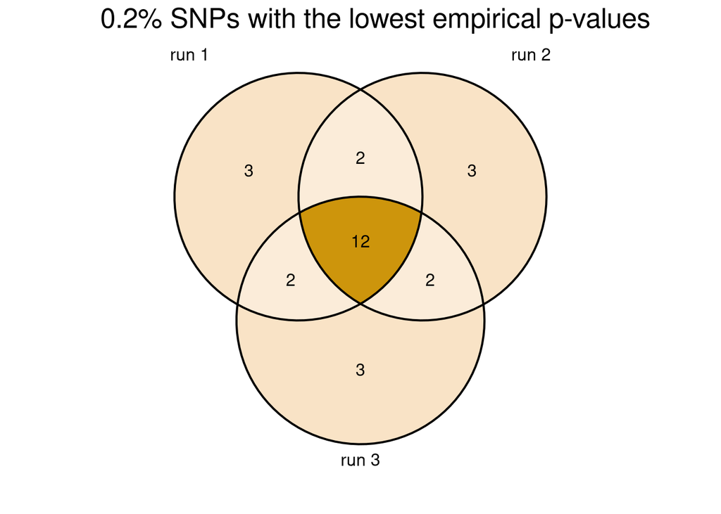

```r
list("run 1"=list_gf_outliers[[1]]$gf_raw$outliers_epv_rank_002,
     "run 2"=list_gf_outliers[[2]]$gf_raw$outliers_epv_rank_002,
     "run 3"=list_gf_outliers[[3]]$gf_raw$outliers_epv_rank_002) %>%
  make_venndiagram(title="0.2% SNPs with the lowest empirical p-values")
```

## Corrected allele frequencies

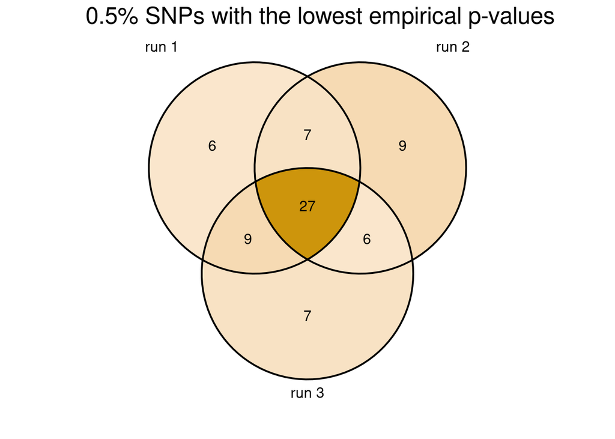

```r
list("run 1"=list_gf_outliers[[1]]$gf_X$outliers_epv_rank_005,
     "run 2"=list_gf_outliers[[2]]$gf_X$outliers_epv_rank_005,
     "run 3"=list_gf_outliers[[3]]$gf_X$outliers_epv_rank_005) %>%
  make_venndiagram(title="0.5% SNPs with the lowest empirical p-values")
```

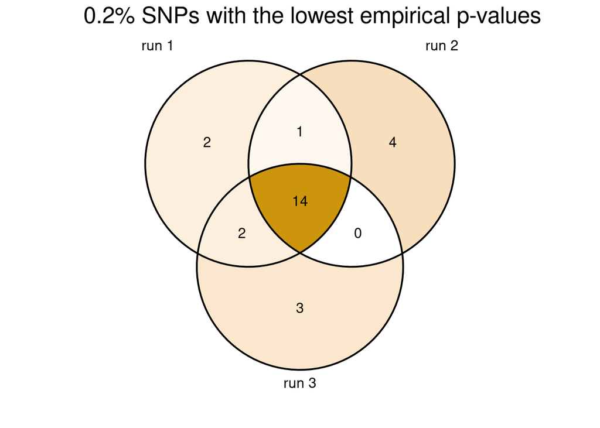

```r
list("run 1"=list_gf_outliers[[1]]$gf_X$outliers_epv_rank_002,
     "run 2"=list_gf_outliers[[2]]$gf_X$outliers_epv_rank_002,
     "run 3"=list_gf_outliers[[3]]$gf_X$outliers_epv_rank_002) %>%
  make_venndiagram(title="0.2% SNPs with the lowest empirical p-values")
```

# Keeping common outliers across runs

## Raw allele frequencies

For the following analyses, we keep the common outliers across the three runs based on raw allele frequencies, i.e., outlier SNPs that were among the 0.5% SNPs with the lowest empirical $p$-values in each of the three successive runs.

```r
cand <- list("run 1"=list_gf_outliers[[1]]$gf_raw$outliers_epv_rank_005,
             "run 2"=list_gf_outliers[[2]]$gf_raw$outliers_epv_rank_005,
             "run 3"=list_gf_outliers[[3]]$gf_raw$outliers_epv_rank_005)%>%
  Reduce(intersect, .)

saveRDS(cand, here::here("outputs/GF/GFCommonOutliers_ThreeRuns_RawAlleleFrequencies.rds"))
```

In the following steps, we use those 40 outlier SNPs.

## Corrected allele frequencies

```r
cand_X <- list("run 1"=list_gf_outliers[[1]]$gf_X$outliers_epv_rank_005,
               "run 2"=list_gf_outliers[[2]]$gf_X$outliers_epv_rank_005,
               "run 3"=list_gf_outliers[[3]]$gf_X$outliers_epv_rank_005)%>%
  Reduce(intersect, .)
```

27 outlier SNPs were in the common across the three runs based on the corrected allele frequencies. We do not use those outliers in the following analyses.

# Common outliers across raw vs corrected allele frequencies

We use the outliers in common across the three successive runs (those identified in the previous section), i.e., the 40 outlier SNPs in common across the three runs for the raw allele frequencies and the rank-based threshold of 0.5% and the 27 outlier SNPs in common across the three runs for the corrected allele frequencies and the rank-based threshold of 0.5%.

**No outliers in common** between those identified with raw allele frequencies and those identified with corrected allele frequencies!

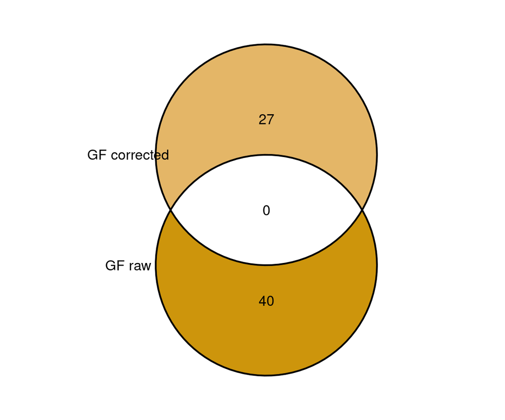

```r
list("GF raw"=list(list_gf_outliers[[1]]$gf_raw$outliers_epv_rank_005,
                                   list_gf_outliers[[2]]$gf_raw$outliers_epv_rank_005,
                                   list_gf_outliers[[3]]$gf_raw$outliers_epv_rank_005) %>%
       Reduce(intersect, .),
     "GF corrected"=list(list_gf_outliers[[1]]$gf_X$outliers_epv_rank_005,
                                         list_gf_outliers[[2]]$gf_X$outliers_epv_rank_005,
                                         list_gf_outliers[[3]]$gf_X$outliers_epv_rank_005) %>%
       Reduce(intersect, .)) %>%
   make_venndiagram()
```

# Common outliers with RDA

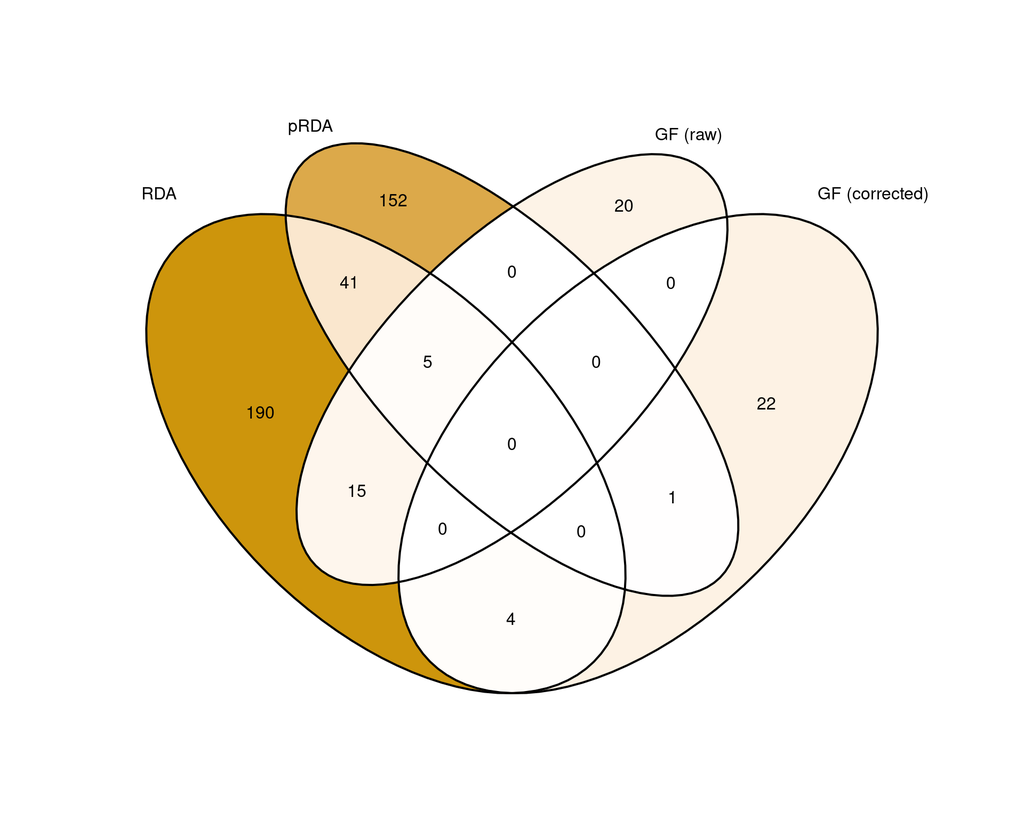

```r
rda_outliers <- readRDS(here::here("outputs/RDA/RDA_outliers.rds"))

list_outliers <- list("RDA" = rda_outliers[[3]]$outliers$snp,
                      "pRDA" = rda_outliers[[4]]$outliers$snp,
                      "GF (raw)" = cand,
                      "GF (corrected)" = cand_X)

list_outliers %>% make_venndiagram()
```

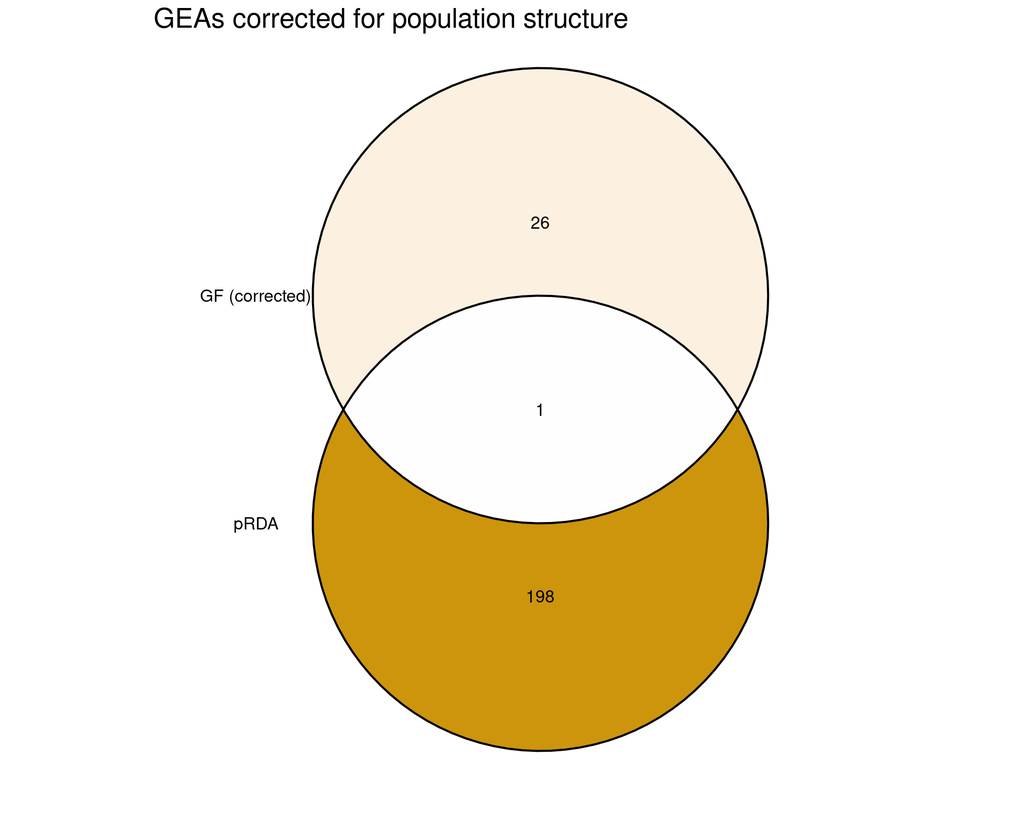

```r
list_outliers[c(2,4)] %>% make_venndiagram(title="GEAs corrected for population structure")
```

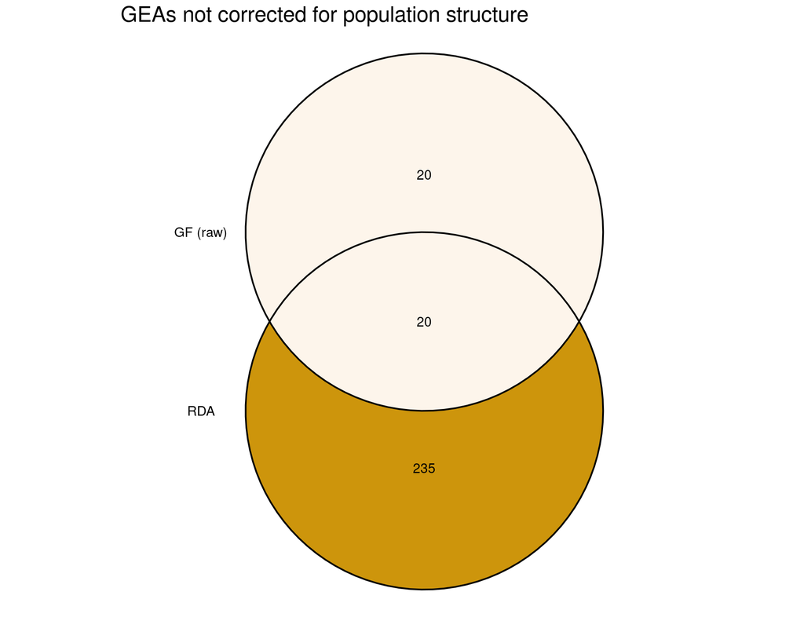

```r
list_outliers[c(1,3)] %>% make_venndiagram(title="GEAs not corrected for population structure")
```

## References

Capblancq, Thibaut, Susanne Lachmuth, Matthew C Fitzpatrick, and Stephen R Keller. 2023. “From Common Gardens to Candidate Genes: Exploring Local Adaptation to Climate in Red Spruce.” *New Phytologist* 237 (5): 1590–1605. https://onlinelibrary.wiley.com/doi/abs/10.1111/nph.18465.

Fitzpatrick, Matthew C, Vikram E Chhatre, Raju Y Soolanayakanahally, and Stephen R Keller. 2021. “Experimental Support for Genomic Prediction of Climate Maladaptation Using the Machine Learning Approach Gradient Forests.” *Molecular Ecology Resources*. https://onlinelibrary.wiley.com/doi/abs/10.1111/1755-0998.13374.

Gain, Clément, Benedicte Rhone, Philippe Cubry, Israfel Salazar, Florence Forbes, Yves Vigouroux, Flora Jay, and Olivier François. 2023. “A Quantitative Theory for Genomic Offset Statistics.” *bioRxiv*, 2023–01.

Lotterhos, Katie E, and Michael C Whitlock. 2014. “Evaluation of Demographic History and Neutral Parameterization on the Performance of FST Outlier Tests.” *Molecular Ecology* 23 (9): 2178–92. https://onlinelibrary.wiley.com/doi/abs/10.1111/mec.12725.